# Advanced Machine Learning Project

#### Group members: Gaël CAVECCHIA, Nathan DESTREZ, Trisha KUMAR

### Introduction

The main objective of this project, is to be able to build a machine learning model, that can predict the popularity of a song on Spotify, based on various features of the song.

We began this project by finding a dataset collected from the Spotify Web API, that contains contains 169k songs from the year 1921 to year 2020.

The dataset contained 19 columns of different features of the song, including one column for "Popularity". This column contains continuous data, and scores the songs in a range of 0-100, based on their popularity.

Therefore, we defined the "Popularity" as our target variable, and for our projet, we tested different Tree-Based Regression algorithms, to find an optimal model that will be most likely to predict the popularity of a song.

#### Business Need:

We identified a few use cases in which our machine learning model could add value to businesses/ individuals:

- This model could be useful for Spotify, when they want to understand which new songs on the platform could be popular, and how they can push these songs to Spotify users
- This model could help new and upcoming artists, who can put the data of their unreleased songs to predict the popularity of it
- Record labels/ record companies could benefit from this model as well - by being able to predict the popularity of a song, it can help them reduce the risk when investing in new songs by their artists, or even when selecting new artists
- It can help artists and labels understand which features of a song are going to impact the level of popularity

```python
# for package auto reload
%load_ext autoreload
%autoreload 2

# for better rendering of plots in jupyter notebook
%matplotlib inline
```

### Import libraries

```python
# for ml
from sklearn.linear_model import LinearRegression
# base modules
import os
import sys
import copy

# for manipulating data
import numpy as np
import pandas as pd
import math
import dill
import scipy

# for Machine Learning
from sklearn.ensemble import RandomForestRegressor, RandomForestClassifier, BaggingRegressor
from sklearn.tree import DecisionTreeRegressor, DecisionTreeClassifier, plot_tree
from sklearn import metrics
from sklearn.preprocessing import LabelEncoder
from sklearn.model_selection import cross_val_score, KFold, GridSearchCV
from sklearn.calibration import CalibratedClassifierCV
from sklearn.inspection import permutation_importance
from scipy.cluster import hierarchy
from sklearn.metrics import mean_squared_error

# for visualization
from IPython.display import display
from matplotlib import pyplot as plt
# plotly
# seaborn
# altair
```

### Setting up paths directory

```python
# path to repo
# path_to_repo = os.path.dirname(os.getcwd())
path_to_repo = os.path.dirname(os.path.dirname(os.path.realpath('__file__')))
path_to_repo
```

```
'C:\\Users\\Natha\\emlyon-dsaib\\Advanced Machine Learning\\EMLyon-ML-Course-2022-T1-main'
```

```python
path_to_data = os.path.join(path_to_repo,"project_data","")
path_to_data
```

```
'C:\\Users\\Natha\\emlyon-dsaib\\Advanced Machine Learning\\EMLyon-ML-Course-2022-T1-main\\project_data\\'
```

```python
path_to_datasets = os.path.join(path_to_data, 'spotify_data.csv')
print(path_to_datasets)
```

```
C:\Users\Natha\emlyon-dsaib\Advanced Machine Learning\EMLyon-ML-Course-2022-T1-main\project_data\spotify_data.csv
```

```python
path_to_datasets = '{}spotify_data.csv'.format(path_to_data)
print(path_to_datasets)
```

```
C:\Users\Natha\emlyon-dsaib\Advanced Machine Learning\EMLyon-ML-Course-2022-T1-main\project_data\spotify_data.csv
```

```python
sys.path.insert(0, os.path.join(path_to_repo,'src'))

# custom module
from emlyon.utils import *
```

```python
path_to_datasets
```

```
'C:\\Users\\Natha\\emlyon-dsaib\\Advanced Machine Learning\\EMLyon-ML-Course-2022-T1-main\\project_data\\spotify_data.csv'
```

### Data exploration and data cleaning

```python
df_raw = pd.read_csv(path_to_datasets) # Transform the csv into a DataFrame
```

```python
df_raw
```

|  | acousticness | artists | danceability | duration_ms | energy | explicit | id | instrumentalness | key | liveness | loudness | mode | name | popularity | release_date | speechiness | tempo | valence | year |
| --- | --- | --- | --- | --- | --- | --- | --- | --- | --- | --- | --- | --- | --- | --- | --- | --- | --- | --- | --- |
| 0 | 0.9950 | ['Carl Woitschach'] | 0.708 | 158648 | 0.1950 | 0 | 6KbQ3uYMLKb5jDxLF7wYDD | 0.563000 | 10 | 0.1510 | -12.428 | 1 | Singende Bataillone 1. Teil | 0 | 1928 | 0.0506 | 118.469 | 0.7790 | 1928 |
| 1 | 0.9940 | ['Robert Schumann', 'Vladimir Horowitz'] | 0.379 | 282133 | 0.0135 | 0 | 6KuQTIu1KoTTkLXKrwlLPV | 0.901000 | 8 | 0.0763 | -28.454 | 1 | Fantasiestücke, Op. 111: Più tosto lento | 0 | 1928 | 0.0462 | 83.972 | 0.0767 | 1928 |
| 2 | 0.6040 | ['Seweryn Goszczyński'] | 0.749 | 104300 | 0.2200 | 0 | 6L63VW0PibdM1HDSBoqnoM | 0.000000 | 5 | 0.1190 | -19.924 | 0 | Chapter 1.18 - Zamek kaniowski | 0 | 1928 | 0.9290 | 107.177 | 0.8800 | 1928 |
| 3 | 0.9950 | ['Francisco Canaro'] | 0.781 | 180760 | 0.1300 | 0 | 6M94FkXd15sOAOQYRnWPN8 | 0.887000 | 1 | 0.1110 | -14.734 | 0 | Bebamos Juntos - Instrumental (Remasterizado) | 0 | 1928-09-25 | 0.0926 | 108.003 | 0.7200 | 1928 |
| 4 | 0.9900 | ['Frédéric Chopin', 'Vladimir Horowitz'] | 0.210 | 687733 | 0.2040 | 0 | 6N6tiFZ9vLTSOIxkj8qKrd | 0.908000 | 11 | 0.0980 | -16.829 | 1 | Polonaise-Fantaisie in A-Flat Major, Op. 61 | 1 | 1928 | 0.0424 | 62.149 | 0.0693 | 1928 |
| ... | ... | ... | ... | ... | ... | ... | ... | ... | ... | ... | ... | ... | ... | ... | ... | ... | ... | ... | ... |
| 169904 | 0.1730 | ['DripReport', 'Tyga'] | 0.875 | 163800 | 0.4430 | 1 | 4KppkflX7I3vJQk7urOJaS | 0.000032 | 1 | 0.0891 | -7.461 | 1 | Skechers (feat. Tyga) - Remix | 75 | 2020-05-15 | 0.1430 | 100.012 | 0.3060 | 2020 |
| 169905 | 0.0167 | ['Leon Bridges', 'Terrace Martin'] | 0.719 | 167468 | 0.3850 | 0 | 1ehhGlTvjtHo2e4xJFB0SZ | 0.031300 | 8 | 0.1110 | -10.907 | 1 | Sweeter (feat. Terrace Martin) | 64 | 2020-06-08 | 0.0403 | 128.000 | 0.2700 | 2020 |
| 169906 | 0.5380 | ['Kygo', 'Oh Wonder'] | 0.514 | 180700 | 0.5390 | 0 | 52eycxprLhK3lPcRLbQiVk | 0.002330 | 7 | 0.1080 | -9.332 | 1 | How Would I Know | 70 | 2020-05-29 | 0.1050 | 123.700 | 0.1530 | 2020 |
| 169907 | 0.0714 | ['Cash Cash', 'Andy Grammer'] | 0.646 | 167308 | 0.7610 | 0 | 3wYOGJYD31sLRmBgCvWxa4 | 0.000000 | 1 | 0.2220 | -2.557 | 1 | I Found You | 70 | 2020-02-28 | 0.0385 | 129.916 | 0.4720 | 2020 |
| 169908 | 0.1090 | ['Ingrid Andress'] | 0.512 | 214787 | 0.4280 | 0 | 60RFlt48hm0l4Fu0JoccOl | 0.000000 | 0 | 0.1050 | -7.387 | 1 | More Hearts Than Mine | 65 | 2020-03-27 | 0.0271 | 80.588 | 0.3660 | 2020 |

169909 rows × 19 columns

```python
df_raw.shape
```

```
(169909, 19)
```

```python
# drop irrelevant features:

df_raw.drop('artists', inplace=True, axis=1)
df_raw.drop('id', inplace=True, axis=1)
df_raw.drop('name', inplace=True, axis=1)
```

```python
df_raw.shape
```

```
(169909, 16)
```

```python
def display_all(df):
    with pd.option_context("display.max_rows", 1000, "display.max_columns", 1000):
        display(df)

display_all(df_raw.head().T)
```

|  | 0 | 1 | 2 | 3 | 4 |
| --- | --- | --- | --- | --- | --- |
| acousticness | 0.995 | 0.994 | 0.604 | 0.995 | 0.99 |
| danceability | 0.708 | 0.379 | 0.749 | 0.781 | 0.21 |
| duration_ms | 158648 | 282133 | 104300 | 180760 | 687733 |
| energy | 0.195 | 0.0135 | 0.22 | 0.13 | 0.204 |
| explicit | 0 | 0 | 0 | 0 | 0 |
| instrumentalness | 0.563 | 0.901 | 0.0 | 0.887 | 0.908 |
| key | 10 | 8 | 5 | 1 | 11 |
| liveness | 0.151 | 0.0763 | 0.119 | 0.111 | 0.098 |
| loudness | -12.428 | -28.454 | -19.924 | -14.734 | -16.829 |
| mode | 1 | 1 | 0 | 0 | 1 |
| popularity | 0 | 0 | 0 | 0 | 1 |
| release_date | 1928 | 1928 | 1928 | 1928-09-25 | 1928 |
| speechiness | 0.0506 | 0.0462 | 0.929 | 0.0926 | 0.0424 |
| tempo | 118.469 | 83.972 | 107.177 | 108.003 | 62.149 |
| valence | 0.779 | 0.0767 | 0.88 | 0.72 | 0.0693 |
| year | 1928 | 1928 | 1928 | 1928 | 1928 |

```python
df_raw.popularity #Target
```

```
0          0
1          0
2          0
3          0
4          1
          ..
169904    75
169905    64
169906    70
169907    70
169908    65
Name: popularity, Length: 169909, dtype: int64
```

```python
df_raw.popularity.describe() #Popularity values within the range of 0 to 100
```

```
count    169909.000000
mean         31.556610
std          21.582614
min           0.000000
25%          12.000000
50%          33.000000
75%          48.000000
max         100.000000
Name: popularity, dtype: float64
```

```python
df_raw.release_date # 'release_date' got differents values formats. We need to clean the column
```

```
0               1928
1               1928
2               1928
3         1928-09-25
4               1928
             ...
169904    2020-05-15
169905    2020-06-08
169906    2020-05-29
169907    2020-02-28
169908    2020-03-27
Name: release_date, Length: 169909, dtype: object
```

```python
df_backup = copy.deepcopy(df_raw) #We save the base DF before transforming the date column.
```

```python
add_datepart(df_raw, 'release_date') #converts 'release_date' to many columns containing the information from the date
```

```
C:\Users\Natha\emlyon-dsaib\Advanced Machine Learning\EMLyon-ML-Course-2022-T1-main\src\emlyon\utils.py:161: FutureWarning: Series.dt.weekofyear and Series.dt.week have been deprecated. Please use Series.dt.isocalendar().week instead.
  for n in attr: df[targ_pre + n] = getattr(fld.dt, n.lower())
```

```python
print(df_raw.shape) #The new df after appplying the add_datepart function got 28 columns
print(df_backup.shape)
```

```
(169909, 28)
(169909, 16)
```

```python
display_all(df_raw.head().T)
```

|  | 0 | 1 | 2 | 3 | 4 |
| --- | --- | --- | --- | --- | --- |
| acousticness | 0.995 | 0.994 | 0.604 | 0.995 | 0.99 |
| danceability | 0.708 | 0.379 | 0.749 | 0.781 | 0.21 |
| duration_ms | 158648 | 282133 | 104300 | 180760 | 687733 |
| energy | 0.195 | 0.0135 | 0.22 | 0.13 | 0.204 |
| explicit | 0 | 0 | 0 | 0 | 0 |
| instrumentalness | 0.563 | 0.901 | 0.0 | 0.887 | 0.908 |
| key | 10 | 8 | 5 | 1 | 11 |
| liveness | 0.151 | 0.0763 | 0.119 | 0.111 | 0.098 |
| loudness | -12.428 | -28.454 | -19.924 | -14.734 | -16.829 |
| mode | 1 | 1 | 0 | 0 | 1 |
| popularity | 0 | 0 | 0 | 0 | 1 |
| speechiness | 0.0506 | 0.0462 | 0.929 | 0.0926 | 0.0424 |
| tempo | 118.469 | 83.972 | 107.177 | 108.003 | 62.149 |
| valence | 0.779 | 0.0767 | 0.88 | 0.72 | 0.0693 |
| year | 1928 | 1928 | 1928 | 1928 | 1928 |
| release_Year | 1928 | 1928 | 1928 | 1928 | 1928 |
| release_Month | 1 | 1 | 1 | 9 | 1 |
| release_Week | 52 | 52 | 52 | 39 | 52 |
| release_Day | 1 | 1 | 1 | 25 | 1 |
| release_Dayofweek | 6 | 6 | 6 | 1 | 6 |
| release_Dayofyear | 1 | 1 | 1 | 269 | 1 |
| release_Is_month_end | False | False | False | False | False |
| release_Is_month_start | True | True | True | False | True |
| release_Is_quarter_end | False | False | False | False | False |
| release_Is_quarter_start | True | True | True | False | True |
| release_Is_year_end | False | False | False | False | False |
| release_Is_year_start | True | True | True | False | True |
| release_Elapsed | -1325462400 | -1325462400 | -1325462400 | -1302307200 | -1325462400 |

```python
df_raw.isnull().describe() #We checked our data for null values, but found out that our dataset did not contain any null values
```

|  | acousticness | danceability | duration_ms | energy | explicit | instrumentalness | key | liveness | loudness | mode | ... | release_Day | release_Dayofweek | release_Dayofyear | release_Is_month_end | release_Is_month_start | release_Is_quarter_end | release_Is_quarter_start | release_Is_year_end | release_Is_year_start | release_Elapsed |
| --- | --- | --- | --- | --- | --- | --- | --- | --- | --- | --- | --- | --- | --- | --- | --- | --- | --- | --- | --- | --- | --- |
| count | 169909 | 169909 | 169909 | 169909 | 169909 | 169909 | 169909 | 169909 | 169909 | 169909 | ... | 169909 | 169909 | 169909 | 169909 | 169909 | 169909 | 169909 | 169909 | 169909 | 169909 |
| unique | 1 | 1 | 1 | 1 | 1 | 1 | 1 | 1 | 1 | 1 | ... | 1 | 1 | 1 | 1 | 1 | 1 | 1 | 1 | 1 | 1 |
| top | False | False | False | False | False | False | False | False | False | False | ... | False | False | False | False | False | False | False | False | False | False |
| freq | 169909 | 169909 | 169909 | 169909 | 169909 | 169909 | 169909 | 169909 | 169909 | 169909 | ... | 169909 | 169909 | 169909 | 169909 | 169909 | 169909 | 169909 | 169909 | 169909 | 169909 |

4 rows × 28 columns

```python
#Our duration column was in miliseconds, we converted this column into minutes to make it more understandable

df_raw["duration_min"] = round(df_raw["duration_ms"]/60000,1)
df_raw["duration_min"]
```

```
0          2.6
1          4.7
2          1.7
3          3.0
4         11.5
          ...
169904     2.7
169905     2.8
169906     3.0
169907     2.8
169908     3.6
Name: duration_min, Length: 169909, dtype: float64
```

```python
df_raw = df_raw.drop(columns=["duration_ms"], axis=1) #Drop the duration millisecond column
```

```python
display_all(df_raw.head().T)
```

|  | 0 | 1 | 2 | 3 | 4 |
| --- | --- | --- | --- | --- | --- |
| acousticness | 0.995 | 0.994 | 0.604 | 0.995 | 0.99 |
| danceability | 0.708 | 0.379 | 0.749 | 0.781 | 0.21 |
| energy | 0.195 | 0.0135 | 0.22 | 0.13 | 0.204 |
| explicit | 0 | 0 | 0 | 0 | 0 |
| instrumentalness | 0.563 | 0.901 | 0.0 | 0.887 | 0.908 |
| key | 10 | 8 | 5 | 1 | 11 |
| liveness | 0.151 | 0.0763 | 0.119 | 0.111 | 0.098 |
| loudness | -12.428 | -28.454 | -19.924 | -14.734 | -16.829 |
| mode | 1 | 1 | 0 | 0 | 1 |
| popularity | 0 | 0 | 0 | 0 | 1 |
| speechiness | 0.0506 | 0.0462 | 0.929 | 0.0926 | 0.0424 |
| tempo | 118.469 | 83.972 | 107.177 | 108.003 | 62.149 |
| valence | 0.779 | 0.0767 | 0.88 | 0.72 | 0.0693 |
| year | 1928 | 1928 | 1928 | 1928 | 1928 |
| release_Year | 1928 | 1928 | 1928 | 1928 | 1928 |
| release_Month | 1 | 1 | 1 | 9 | 1 |
| release_Week | 52 | 52 | 52 | 39 | 52 |
| release_Day | 1 | 1 | 1 | 25 | 1 |
| release_Dayofweek | 6 | 6 | 6 | 1 | 6 |
| release_Dayofyear | 1 | 1 | 1 | 269 | 1 |
| release_Is_month_end | False | False | False | False | False |
| release_Is_month_start | True | True | True | False | True |
| release_Is_quarter_end | False | False | False | False | False |
| release_Is_quarter_start | True | True | True | False | True |
| release_Is_year_end | False | False | False | False | False |
| release_Is_year_start | True | True | True | False | True |
| release_Elapsed | -1325462400 | -1325462400 | -1325462400 | -1302307200 | -1325462400 |
| duration_min | 2.6 | 4.7 | 1.7 | 3.0 | 11.5 |

### Save preprocessed data:

```python
# Let's save our preprocessed data:

path_to_tmp = os.path.join(path_to_repo, "data")
path_to_tmp
```

```
'C:\\Users\\Natha\\emlyon-dsaib\\Advanced Machine Learning\\EMLyon-ML-Course-2022-T1-main\\data'
```

```python
os.makedirs(path_to_tmp, exist_ok = True)
```

```python
path_to_spotify_raw = os.path.join(path_to_tmp, 'spotify-raw')
```

```python
path_to_spotify_raw
```

```
'C:\\Users\\Natha\\emlyon-dsaib\\Advanced Machine Learning\\EMLyon-ML-Course-2022-T1-main\\data\\spotify-raw'
```

```python
# feather version:
df_raw.to_feather(path_to_spotify_raw)
```

```python
# csv version:
df_raw.to_csv(path_to_spotify_raw + '.csv', index = False)
```

### Split data

```python
def split_vals(df, n):
    return df[:n].copy(), df[n:].copy()
```

```python
df, y, nas = proc_df(df_raw, 'popularity') # changes the df into an entirely numeric dataframe
```

```python
n_total = len(df_raw)
n_valid = 51000 #30% of the total data set
n_train = n_total - n_valid
n_small = 20000

print('full number of data points : {}'.format(n_total))
print('number of validation data points : {}'.format(n_valid))
print('number of training data points : {}'.format(n_train))
print('number of subsampled training points : {}'.format(n_small))
```

```
full number of data points : 169909
number of validation data points : 51000
number of training data points : 118909
number of subsampled training points : 20000
```

```python
X_train, X_valid = split_vals(df, n_train)
y_train, y_valid = split_vals(y, n_train)

X_small, _ = split_vals(X_train, n_small)
y_small, _ = split_vals(y_train, n_small)

print('Number of small training data points: X = {}, y = {}'.format(X_small.shape, y_small.shape))
print('Number of full training data points: X = {}, y = {}'.format(X_train.shape, y_train.shape))
print('Number of validation data points: X = {}, y = {}'.format(X_valid.shape, y_valid.shape))
```

```
Number of small training data points: X = (20000, 27), y = (20000,)
Number of full training data points: X = (118909, 27), y = (118909,)
Number of validation data points: X = (51000, 27), y = (51000,)
```

```python
def rmse(y_gold, y_pred):
    return math.sqrt(((y_gold - y_pred)**2).mean())
```

```python
def print_score(m, X_train, y_train, X_valid, y_valid):
    print('RMSE on train set: {:.4f}'.format(rmse(m.predict(X_train), y_train)))
    print('RMSE on valid set: {:.4f}'.format(rmse(m.predict(X_valid), y_valid)))
    print('R^2 on train set: {:.4f}'.format(m.score(X_train, y_train)))
    print('R^2 on valid set: {:.4f}'.format(m.score(X_valid, y_valid)))
    if hasattr(m, 'oob_score_'): print('R^2 on oob set: {:.4f}'.format(m.oob_score_))
    return
```

```python
# Base model on a small dataset
base_model = RandomForestRegressor(n_estimators = 10, n_jobs = -1, random_state = 42)

%time base_model.fit(X_small, y_small)
print_score(base_model, X_small, y_small, X_valid, y_valid)
```

```
CPU times: total: 2.77 s
Wall time: 585 ms
RMSE on train set: 1.8448
RMSE on valid set: 6.4071
R^2 on train set: 0.9910
R^2 on valid set: 0.9073
```

```python
# Base model on full training data
base_model = RandomForestRegressor(n_estimators = 10, n_jobs = -1, random_state = 42)

%time base_model.fit(X_train, y_train)
print_score(base_model, X_train, y_train, X_valid, y_valid)
```

```
CPU times: total: 20.1 s
Wall time: 4.23 s
RMSE on train set: 4.3995
RMSE on valid set: 6.3365
R^2 on train set: 0.9593
R^2 on valid set: 0.9093
```

The R^2 score on our base model shows that our model is overfitting, and therefore we will try changing parameters, to get a final model that does not overfit

### Testing the DecisionTreeRegressor model

```python
model_dt = DecisionTreeRegressor(
    criterion = 'squared_error', # 'mse',
    splitter = 'best',
    max_depth = 3,
    min_samples_split = 2,
    min_samples_leaf = 1,
    min_weight_fraction_leaf = 0.0,
    max_features = 'auto',
    max_leaf_nodes = None,
    min_impurity_decrease = 0.0,
    random_state = 42, # None,
    ccp_alpha = 0.0,
)
%time model_dt.fit(X_small, y_small)
print_score(model_dt, X_small, y_small, X_valid, y_valid)
```

```
CPU times: total: 93.8 ms
Wall time: 93.1 ms
RMSE on train set: 5.0211
RMSE on valid set: 7.0656
R^2 on train set: 0.9330
R^2 on valid set: 0.8873
```

```python
scores = cross_val_score(model_dt, X_small, y_small, cv = 5, n_jobs = -1)

print(scores)
print("r2 is {:.3f} with a standard deviation of {:.3f}".format(scores.mean(), scores.std()))
```

```
[0.92597512 0.68419527 0.9169806  0.64881978 0.89771846]
r2 is 0.815 with a standard deviation of 0.122
```

The scores on this model show that our model is still overfitting slightly

### Testing the RandomForestRegressor model

```python
base_model = RandomForestRegressor(

    random_state = 42,
    bootstrap = True,
    oob_score = True,
)

%time base_model.fit(X_small, y_small)
print_score(base_model, X_small, y_small, X_valid, y_valid)
```

```
CPU times: total: 23.2 s
Wall time: 23.3 s
RMSE on train set: 1.5355
RMSE on valid set: 6.2639
R^2 on train set: 0.9937
R^2 on valid set: 0.9114
R^2 on oob set: 0.9546
```

```python
model_rf = RandomForestRegressor(
    # parameters shared with DecisionTreeRegressor
    n_estimators = 10, # 100 # 1 = the model is a single tree
    criterion = 'squared_error',
    max_depth = 3, # None
    min_samples_split = 2,
    min_samples_leaf = 1,
    min_weight_fraction_leaf = 0.0,
    max_features = 'auto',
    max_leaf_nodes = None,
    min_impurity_decrease = 0.0,
    ccp_alpha = 0.0,
    random_state = 42, # None,

    # RandomForestRegressor specific hyperparameters
    bootstrap = False, # default = True
    oob_score = False,
    max_samples = None,

    # extra parameters
    warm_start = False,
    n_jobs = -1, # None
    verbose = 0,
)
```

```python
%time model_rf.fit(X_small, y_small)
print_score(model_rf, X_small, y_small, X_valid, y_valid)
```

```
CPU times: total: 766 ms
Wall time: 200 ms
RMSE on train set: 5.0211
RMSE on valid set: 7.0655
R^2 on train set: 0.9330
R^2 on valid set: 0.8873
```

```python
scores = cross_val_score(model_rf, X_small, y_small, cv = 5, n_jobs = -1)

print(scores)
print("r2 is {:.3f} with a standard deviation of {:.3f}".format(scores.mean(), scores.std()))
```

```
[0.92597512 0.68419527 0.91698516 0.64881978 0.89771846]
r2 is 0.815 with a standard deviation of 0.122
```

```python
draw_tree(model_rf.estimators_[0], X_small, precision = 3)
```

[figure not shown]

This model produced scores that are very similar to our previous Decision tree model. Based on the R^2 scores, the model is still slightly overfitting, and while there is a very small difference in the RMSE score, the model still needs to be improved

### Bagging Model

```python
model_b = BaggingRegressor(
    base_estimator = base_model,
    n_estimators = 28,

    max_features = 0.9,
    max_samples = 1.0,

    bootstrap = True,
    bootstrap_features = False,
    oob_score = True,

    warm_start = False,
    n_jobs = -1,
    random_state = 42,
    verbose = 0,
)

%time model_b.fit(X_small, y_small)
print_score(model_b, X_small, y_small, X_valid, y_valid)
```

```
CPU times: total: 12.6 s
Wall time: 1min 18s
RMSE on train set: 2.4368
RMSE on valid set: 6.2488
R^2 on train set: 0.9842
R^2 on valid set: 0.9118
R^2 on oob set: 0.9570
```

```python
#Prends trop de temps

# scores = cross_val_score(model_b, X_small, y_small, cv = 5, n_jobs = -1)

# print(scores)
# print("r2 is {:.3f} with a standard deviation of {:.3f}".format(scores.mean(), scores.std()))
```

### Model Selection

Out of the three models we tried, we chose the Random Forest Regressor as the model we want to conitnue to improve, as it produced the best results out of the three, without taking too much time to run

### Tree bagging

```python
model_rf = RandomForestRegressor(
    # parameters shared with DecisionTreeRegressor
    n_estimators = 30, # 100 # 1 = the model is a single tree
    criterion = 'squared_error',
    max_depth = 15, # None
    min_samples_split = 2,
    min_samples_leaf = 1,
    min_weight_fraction_leaf = 0.0,
    max_features = 'auto',
    max_leaf_nodes = None,
    min_impurity_decrease = 0.0,
    ccp_alpha = 0.0,
    random_state = 42, # None,

    # RandomForestRegressor specific hyperparameters
    bootstrap = True, # default = True
    oob_score = False,
    max_samples = None,

    # extra parameters
    warm_start = False,
    n_jobs = -1, # None
    verbose = 0,
)

%time model_rf.fit(X_small, y_small)
print_score(model_rf, X_small, y_small, X_valid, y_valid)
```

```
CPU times: total: 6.88 s
Wall time: 1.05 s
RMSE on train set: 2.2815
RMSE on valid set: 6.3243
R^2 on train set: 0.9862
R^2 on valid set: 0.9097
```

```python
# using bootstrap:

# slight decrease in RMSE
# slight increase in R2 on the training set
# slight increase in R2 on the valid set
# overfitting
```

```python
# all tree predictions on all data
preds = np.stack([tree.predict(X_valid) for tree in model_rf.estimators_]) # or np.asarray()

# predictions of the 10 trees, mean, and actual value (for first point in validation set)
preds.shape, preds[:,0], np.mean(preds[:,0]), y_valid[0]
```

[output not shown]

```
((30, 51000),
 array([0.00244499, 0.01136364, 0.        , 0.04130435, 0.01098901,
        0.31818182, 0.01328904, 0.        , 0.        , 0.        ,
        0.05021834, 2.        , 0.0262069 , 0.33333333, 0.        ,
        0.11494253, 0.04092072, 0.        , 0.23214286, 0.00610998,
        0.        , 0.        , 0.16455696, 0.02216749, 0.09848485,
        0.01528384, 0.00236967, 0.11937173, 0.11751904, 0.01973684]),
 0.12536459704429279,
 0)
```

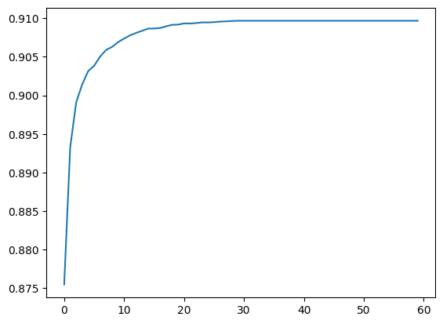

```python
plt.plot([
    metrics.r2_score(y_valid, np.mean(preds[:num_trees], axis = 0))
    for num_trees in range(1, 61)
])
```

```python
# The slope clearly indicates that going above 30 estimators won't help that much, it would be a waste of computing resources.
```

```python
# on the full training set:

model_rf_fulldata = RandomForestRegressor(
    # parameters shared with DecisionTreeRegressor
    n_estimators = 30, # 100 # 1 = the model is a single tree
    criterion = 'squared_error',
    max_depth = 15, # None
    min_samples_split = 2,
    min_samples_leaf = 1,
    min_weight_fraction_leaf = 0.0,
    max_features = 'auto',
    max_leaf_nodes = None,
    min_impurity_decrease = 0.0,
    ccp_alpha = 0.0,
    random_state = 42, # None,

    # RandomForestRegressor specific hyperparameters
    bootstrap = True, # default = True
    oob_score = False,
    max_samples = None,

    # extra parameters
    warm_start = False,
    n_jobs = -1, # None
    verbose = 0,
)

%time model_rf_fulldata.fit(X_train, y_train)
print_score(model_rf_fulldata, X_train, y_train, X_valid, y_valid)
```

```
CPU times: total: 41.8 s
Wall time: 5.94 s
RMSE on train set: 7.7989
RMSE on valid set: 5.4037
R^2 on train set: 0.8721
R^2 on valid set: 0.9341
```

### Calculating OOB Score

- The OOB score tests the model on the out of bag sample of our dataset, when using Random Forest. We want to have a look at this score as another metric than can allow us to understand whether our model is overfitting

```python
model_rf = RandomForestRegressor(
    # parameters shared with DecisionTreeRegressor
    n_estimators = 30, # 100 # 1 = the model is a single tree
    criterion = 'squared_error',
    max_depth = 15, # None
    min_samples_split = 2,
    min_samples_leaf = 1,
    min_weight_fraction_leaf = 0.0,
    max_features = 'auto',
    max_leaf_nodes = None,
    min_impurity_decrease = 0.0,
    ccp_alpha = 0.0,
    random_state = 42, # None,

    # RandomForestRegressor specific hyperparameters
    bootstrap = True, # default = True
    oob_score = True,
    max_samples = None,

    # extra parameters
    warm_start = False,
    n_jobs = -1, # None
    verbose = 0,
)

%time model_rf.fit(X_small, y_small)
print_score(model_rf, X_small, y_small, X_valid, y_valid)
```

```
CPU times: total: 6.8 s
Wall time: 1.06 s
RMSE on train set: 2.2815
RMSE on valid set: 6.3243
R^2 on train set: 0.9862
R^2 on valid set: 0.9097
R^2 on oob set: 0.9528
```

```python
model_rf_withoob = RandomForestRegressor(
    # parameters shared with DecisionTreeRegressor
    n_estimators = 30, # 100 # 1 = the model is a single tree
    criterion = 'squared_error',
    max_depth = 15, # None
    min_samples_split = 2,
    min_samples_leaf = 1,
    min_weight_fraction_leaf = 0.0,
    max_features = 'auto',
    max_leaf_nodes = None,
    min_impurity_decrease = 0.0,
    ccp_alpha = 0.0,
    random_state = 42, # None,

    # RandomForestRegressor specific hyperparameters
    bootstrap = True, # default = True
    oob_score = True, # oob score true, default is False
    max_samples = None,

    # extra parameters
    warm_start = False,
    n_jobs = -1, # None
    verbose = 0,
)

%time model_rf_withoob.fit(X_train, y_train)
print_score(model_rf_withoob, X_train, y_train, X_valid, y_valid)
```

```
CPU times: total: 42.6 s
Wall time: 6.36 s
RMSE on train set: 7.7989
RMSE on valid set: 5.4037
R^2 on train set: 0.8721
R^2 on valid set: 0.9341
R^2 on oob set: 0.7928
```

### Stopping Criteria

- For the stopping criteria, we will play with the features min_samples_split and min_simples_leaf, to stop the decision trees from growing too deep, and to prevent our model from overfitting

```python
model = RandomForestRegressor(
    n_estimators = 28,
    criterion = 'squared_error',

    # stoping criteria
    max_depth = 5,
    min_samples_split = 2,
    min_samples_leaf = 1,
    min_weight_fraction_leaf = 0.0,
    max_leaf_nodes = None,
    min_impurity_decrease = 0.0,
    ccp_alpha = 0.0,

    # bagging parameters
    max_features = 'auto',
    bootstrap = True,
    oob_score = True,
    max_samples = None,

    # other
    warm_start = False,
    n_jobs = -1, # None
    random_state = 42, # None,
    verbose = 0,
)

%time model.fit(X_small, y_small)
print_score(model, X_small, y_small, X_valid, y_valid)
```

```
CPU times: total: 2.47 s
Wall time: 443 ms
RMSE on train set: 4.0530
RMSE on valid set: 6.4425
R^2 on train set: 0.9564
R^2 on valid set: 0.9063
R^2 on oob set: 0.9535
```

Final model after multiple tries

#### Data subsampling

- Playing with max_samples hyperparameter:

```python
model = RandomForestRegressor(
    n_estimators = 28,
    criterion = 'squared_error',

    # stoping criteria
    max_depth = 5,
    min_samples_split = 2,
    min_samples_leaf = 1,
    min_weight_fraction_leaf = 0.0,
    max_leaf_nodes = None,
    min_impurity_decrease = 0.0,
    ccp_alpha = 0.0,

    # bagging parameters
    max_features = 'auto',
    bootstrap = True,
    oob_score = True,
    max_samples = 0.1, #set to 0.1

    # other
    warm_start = False,
    n_jobs = -1, # None
    random_state = 42, # None,
    verbose = 0,
)

%time model.fit(X_small, y_small)
print_score(model, X_small, y_small, X_valid, y_valid)
```

```
CPU times: total: 781 ms
Wall time: 259 ms
RMSE on train set: 4.0974
RMSE on valid set: 6.4825
R^2 on train set: 0.9554
R^2 on valid set: 0.9051
R^2 on oob set: 0.9540
```

#### Features subsampling

- Play with max_features to increase the model generalization

```python
import logging
from collections import OrderedDict
```

[output not shown]

[output cut: 55 more lines]

[output not shown]

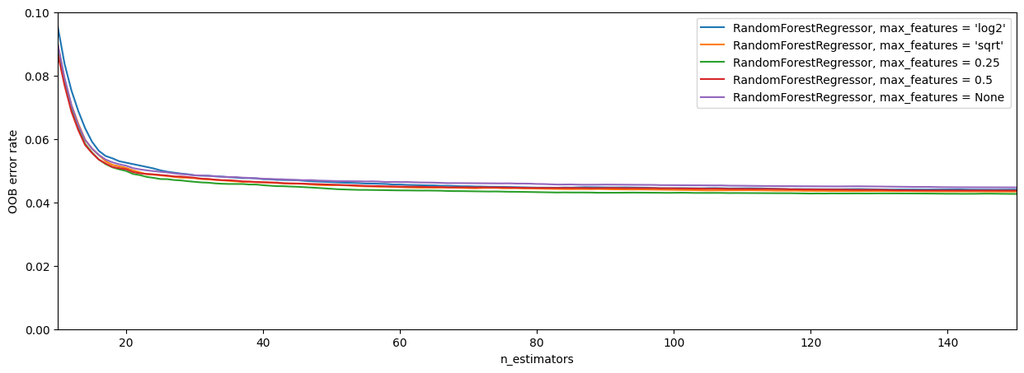

```python
logging.info('warn')

# NOTE: Setting the `warm_start` construction parameter to `True` disables
# support for parallelized ensembles but is necessary for tracking the OOB
# error trajectory during training.
ensemble_clfs = [
    ("RandomForestRegressor, max_features = 'log2'",
        RandomForestRegressor(
            warm_start = True,
            oob_score = True,
            max_features = "log2",
            random_state = 42)),
    ("RandomForestRegressor, max_features = 'sqrt'",
        RandomForestRegressor(
            warm_start = True,
            oob_score = True,
            max_features = "sqrt",
            random_state = 42)),
    ("RandomForestRegressor, max_features = 0.25",
        RandomForestRegressor(
            warm_start = True,
            oob_score = True,
            max_features = 0.25,
            random_state = 42)),
    ("RandomForestRegressor, max_features = 0.5",
        RandomForestRegressor(
            warm_start = True,
            oob_score = True,
            max_features = 0.5,
            random_state = 42)),
    ("RandomForestRegressor, max_features = None",
        RandomForestRegressor(
            warm_start = True,
            oob_score = True,
            max_features = None,
            random_state = 42)),
]

# Map a classifier name to a list of (<n_estimators>, <error rate>) pairs.
error_rate = OrderedDict((label, []) for label, _ in ensemble_clfs)

# Range of `n_estimators` values to explore.
min_estimators = 10
max_estimators = 150

for label, clf in ensemble_clfs:
    for i in range(min_estimators, max_estimators + 1):
        clf.set_params(n_estimators = i)
        clf.fit(X_small, y_small)

        # Record the OOB error for each `n_estimators=i` setting.
        oob_error = 1 - clf.oob_score_
        error_rate[label].append((i, oob_error))

# Generate the "OOB error rate" vs. "n_estimators" plot.
plt.figure(figsize = (15, 5))
for label, clf_err in error_rate.items():
    xs, ys = zip(*clf_err)
    plt.plot(xs, ys, label = label)

# Show the plot
plt.xlim(min_estimators, max_estimators)
plt.ylim(0., 0.1)
plt.xlabel("n_estimators")
plt.ylabel("OOB error rate")
plt.legend(loc = "upper right")
plt.show()
```

- The graph shows that when we set max_features = 0.25, we get the lowest OOB error rate (as shown from the green line), therefore we will set our max_features to 0.25

```python
model = RandomForestRegressor(
    n_estimators = 28,
    criterion = 'squared_error',

    # stoping criteria
    max_depth = 5,
    min_samples_split = 2,
    min_samples_leaf = 1,
    min_weight_fraction_leaf = 0.0,
    max_leaf_nodes = None,
    min_impurity_decrease = 0.0,
    ccp_alpha = 0.0,

    # bagging parameters
    max_features = 0.25, # play with max_features
    bootstrap = True,
    oob_score = True,
    max_samples = 0.1,

    # other
    warm_start = False,
    n_jobs = -1, # None
    random_state = 42, # None,
    verbose = 0,
)

%time model.fit(X_small, y_small)
print_score(model, X_small, y_small, X_valid, y_valid)
```

```
CPU times: total: 328 ms
Wall time: 187 ms
RMSE on train set: 4.7669
RMSE on valid set: 6.9654
R^2 on train set: 0.9397
R^2 on valid set: 0.8904
R^2 on oob set: 0.9382
```

```python
# on the full data
model = RandomForestRegressor(
    n_estimators = 28,
    criterion = 'squared_error',

    # stoping criteria
    max_depth = 5,
    min_samples_split = 2,
    min_samples_leaf = 1,
    min_weight_fraction_leaf = 0.0,
    max_leaf_nodes = None,
    min_impurity_decrease = 0.0,
    ccp_alpha = 0.0,

    # bagging parameters
    max_features = 0.25,
    bootstrap = True,
    oob_score = True,
    max_samples = 0.1,

    # other
    warm_start = False,
    n_jobs = -1, # None
    random_state = 42, # None,
    verbose = 0,
)

%time model.fit(X_train, y_train)
print_score(model, X_train, y_train, X_valid, y_valid)
```

```
CPU times: total: 1.52 s
Wall time: 798 ms
RMSE on train set: 10.4229
RMSE on valid set: 5.7961
R^2 on train set: 0.7715
R^2 on valid set: 0.9241
R^2 on oob set: 0.7706
```

```python
scores = cross_val_score(model, X_small, y_small, cv = 5, n_jobs = -1)

print(scores)
print("r2 is {:.3f} with a standard deviation of {:.3f}".format(scores.mean(), scores.std()))
```

```
[0.92796241 0.73316498 0.91677226 0.71495992 0.89792854]
r2 is 0.838 with a standard deviation of 0.094
```

#### Cross validation

- In this section we generate differents models with differents parameters and use cross validation to compare them. The main goal is to define a set of values for each parameters for the next step

```python
model1 = RandomForestRegressor(
    n_estimators = 28,
    criterion = 'squared_error',

    # stoping criteria
    max_depth = 5,
    min_samples_split = 2,
    min_samples_leaf = 1,
    min_weight_fraction_leaf = 0.0,
    max_leaf_nodes = None,
    min_impurity_decrease = 0.0,
    ccp_alpha = 0.0,

    # bagging parameters
    max_features = 0.25,
    bootstrap = True,
    oob_score = True,
    max_samples = 0.1,

    # other
    warm_start = False,
    n_jobs = -1, # None
    random_state = 42, # None,
    verbose = 0,
)

# randomized splitting strategy
cv = KFold(n_splits = 8, shuffle = True, random_state = 42)

scores = cross_val_score(model1, X_small, y_small, cv = cv, n_jobs = -1)

print(scores)
print("r2 is {:.3f} with a standard deviation of {:.3f}".format(scores.mean(), scores.std()))
```

```
[0.94053986 0.93901114 0.93873756 0.94321912 0.93742853 0.94270517
 0.9246891  0.94403519]
r2 is 0.939 with a standard deviation of 0.006
```

```python
model2 = RandomForestRegressor(
    n_estimators = 28,
    criterion = 'squared_error',

    # stoping criteria
    max_depth = 8,
    min_samples_split = 2,
    min_samples_leaf = 6,
    min_weight_fraction_leaf = 0.0,
    max_leaf_nodes = None,
    min_impurity_decrease = 0.0,
    ccp_alpha = 0.0,

    # bagging parameters
    max_features = 0.25,
    bootstrap = True,
    oob_score = True,
    max_samples = 0.1,

    # other
    warm_start = False,
    n_jobs = -1, # None
    random_state = 42, # None,
    verbose = 0,
)

# randomized splitting strategy
cv = KFold(n_splits = 8, shuffle = True, random_state = 42)

scores = cross_val_score(model2, X_small, y_small, cv = cv, n_jobs = -1)

print(scores)
print("r2 is {:.3f} with a standard deviation of {:.3f}".format(scores.mean(), scores.std()))
```

```
[0.94577686 0.9469529  0.94528145 0.94921417 0.94413861 0.95037769
 0.92861092 0.9487022 ]
r2 is 0.945 with a standard deviation of 0.006
```

```python
model3 = RandomForestRegressor(
    n_estimators = 28,
    criterion = 'squared_error',

    # stoping criteria
    max_depth = 7,
    min_samples_split = 2,
    min_samples_leaf = 2,
    min_weight_fraction_leaf = 0.0,
    max_leaf_nodes = None,
    min_impurity_decrease = 0.0,
    ccp_alpha = 0.0,

    # bagging parameters
    max_features = 0.25,
    bootstrap = True,
    oob_score = True,
    max_samples = 0.6,

    # other
    warm_start = False,
    n_jobs = -1, # None
    random_state = 42, # None,
    verbose = 0,
)

# randomized splitting strategy
cv = KFold(n_splits = 8, shuffle = True, random_state = 42)

scores = cross_val_score(model3, X_small, y_small, cv = cv, n_jobs = -1)

print(scores)
print("r2 is {:.3f} with a standard deviation of {:.3f}".format(scores.mean(), scores.std()))
```

```
[0.94781451 0.95174893 0.94879584 0.95223379 0.95491387 0.95534875
 0.94057445 0.95449869]
r2 is 0.951 with a standard deviation of 0.005
```

```python
model4 = RandomForestRegressor(
    n_estimators = 28,
    criterion = 'squared_error',

    # stoping criteria
    max_depth = 7,
    min_samples_split = 2,
    min_samples_leaf = 2,
    min_weight_fraction_leaf = 0.0,
    max_leaf_nodes = None,
    min_impurity_decrease = 0.0,
    ccp_alpha = 0.0,

    # bagging parameters
    max_features = 0.2,
    bootstrap = True,
    oob_score = True,
    max_samples = 0.6,

    # other
    warm_start = False,
    n_jobs = -1, # None
    random_state = 42, # None,
    verbose = 0,
)

# randomized splitting strategy
cv = KFold(n_splits = 8, shuffle = True, random_state = 42)

scores = cross_val_score(model4, X_small, y_small, cv = cv, n_jobs = -1)

print(scores)
print("r2 is {:.3f} with a standard deviation of {:.3f}".format(scores.mean(), scores.std()))
```

```
[0.94740326 0.95282938 0.94667328 0.95090683 0.94827911 0.95262119
 0.93935539 0.95330772]
r2 is 0.949 with a standard deviation of 0.004
```

```python
model5 = RandomForestRegressor(
    n_estimators = 35,
    criterion = 'squared_error',

    # stoping criteria
    max_depth = 10,
    min_samples_split = 2,
    min_samples_leaf = 5,
    min_weight_fraction_leaf = 0.0,
    max_leaf_nodes = None,
    min_impurity_decrease = 0.0,
    ccp_alpha = 0.0,

    # bagging parameters
    max_features = 0.35,
    bootstrap = True,
    oob_score = True,
    max_samples = 0.4,

    # other
    warm_start = False,
    n_jobs = -1, # None
    random_state = 42, # None,
    verbose = 0,
)

# randomized splitting strategy
cv = KFold(n_splits = 8, shuffle = True, random_state = 42)

scores = cross_val_score(model5, X_small, y_small, cv = cv, n_jobs = -1)

print(scores)
print("r2 is {:.3f} with a standard deviation of {:.3f}".format(scores.mean(), scores.std()))
```

```
[0.95090462 0.95832231 0.95333276 0.95613032 0.95631536 0.9577863
 0.94654239 0.95974617]
r2 is 0.955 with a standard deviation of 0.004
```

#### Fine tuning the model (hyperparameter + gridsearchCV)

```python
# several grids can be cast into a list
# here we provide only one grid
param_grid = [
    {'n_estimators': [28, 30, 35],
     'max_depth': [5, 7, 8, 10],
     'min_samples_leaf': [1, 2, 5, 6],
     'max_features': [0.2, 0,3, 0.35, 0.5],
     'max_samples': [0.1, 0.4, 0.6, 0.75],
    },
]
```

```python
model = RandomForestRegressor(
    random_state = 42,
    bootstrap = True,
)
```

```python
tuned_model = GridSearchCV(
    estimator = model,
    param_grid = param_grid,
    scoring = None, # uses estimator's default score method
    n_jobs = -1,
    refit = True, # keep a fitted version of the overall best model
    cv = 5,
    return_train_score = True,
    verbose = 2,
)
```

```python
tuned_model.fit(X_small, y_small)
```

```
Fitting 5 folds for each of 960 candidates, totalling 4800 fits
```

[output not shown]

[output cut: 307 more lines]

[output not shown]

```
GridSearchCV(cv=5, estimator=RandomForestRegressor(random_state=42), n_jobs=-1,
             param_grid=[{'max_depth': [5, 7, 8, 10],
                          'max_features': [0.2, 0, 3, 0.35, 0.5],
                          'max_samples': [0.1, 0.4, 0.6, 0.75],
                          'min_samples_leaf': [1, 2, 5, 6],
                          'n_estimators': [28, 30, 35]}],
             return_train_score=True, verbose=2)
```

```python
best_model = tuned_model.best_estimator_
best_model
```

```
RandomForestRegressor(max_depth=8, max_features=0.5, max_samples=0.75,
                      min_samples_leaf=2, n_estimators=35, random_state=42)
```

- By using grid search on the parameters we have tested previously, we can identify what could potentially be the most optimal parameters that we can use to give us the best model
- We will then fit the new model with the optimal features on our data set

```python
best_model.fit(X_small, y_small)
print_score(best_model, X_small, y_small, X_valid, y_valid)
```

```
RMSE on train set: 3.7564
RMSE on valid set: 6.3825
R^2 on train set: 0.9625
R^2 on valid set: 0.9080
```

```python
best_model.fit(X_train, y_train)
print_score(best_model, X_train, y_train, X_valid, y_valid)
```

```
RMSE on train set: 9.8495
RMSE on valid set: 5.1185
R^2 on train set: 0.7960
R^2 on valid set: 0.9408
```

### Model Interpretation

#### Features importance

As a result of these tests, we concluded that our model is still able to score well, however we did not have time to go deeper into the understanding on how this information could be helpful to further improve our project.

```python
def rf_feat_importance(model, df):
    feat_importance = pd.DataFrame({
        'cols': df.columns,
        'imp': model.feature_importances_,
    })
    feat_importance = feat_importance.sort_values('imp', ascending = False)
    return feat_importance


def rf_unfolded_feat_importance(model, df):
    feat_importance = pd.DataFrame({
        'cols': df.columns,
        'imp': model.feature_importances_,
    })
    for i, tree in enumerate(model.estimators_):
        feat_importance['imp_' + str(i)] = tree.feature_importances_
    feat_importance = feat_importance.sort_values('imp', ascending = False)
    return feat_importance


def tree_feature_importance(model, normalize = True):

    left_c = model.tree_.children_left
    right_c = model.tree_.children_right

    impurity = model.tree_.impurity
    node_samples = model.tree_.weighted_n_node_samples

    # Initialize the feature importance, those not used remain zero
    feature_importance = np.zeros((model.tree_.n_features,))

    for idx, node in enumerate(model.tree_.feature):
        if node >= 0:
            # Accumulate the feature importance over all the nodes where it's used
            feature_importance[node] += (
                impurity[idx]*node_samples[idx] -
                impurity[left_c[idx]]*node_samples[left_c[idx]] -
                impurity[right_c[idx]]*node_samples[right_c[idx]])

    # Number of samples at the root node
    feature_importance /= node_samples[0]

    if normalize:
        normalizer = feature_importance.sum()
        if normalizer > 0:
            feature_importance /= normalizer

    return feature_importance
```

```python
best_model.feature_importances_
```

```
array([5.80221066e-02, 1.38241991e-03, 8.89658130e-03, 1.09087660e-03,
       2.45425239e-03, 1.97214337e-04, 1.70586506e-03, 4.64651836e-03,
       3.56980077e-05, 2.42162313e-03, 5.15654531e-04, 5.99615286e-04,
       1.68561466e-01, 2.07994101e-01, 5.25062177e-04, 6.64797602e-04,
       2.26873630e-03, 9.18293065e-04, 5.28681258e-03, 2.93129556e-05,
       8.64658881e-04, 7.17162526e-06, 8.62078351e-04, 9.52476685e-06,
       1.20561436e-04, 5.26657890e-01, 3.26110773e-03])
```

```python
feat_importance = rf_feat_importance(best_model, X_small)
feat_importance[:20]
```

|  | cols | imp |
| --- | --- | --- |
| 25 | release_Elapsed | 0.526658 |
| 13 | release_Year | 0.207994 |
| 12 | year | 0.168561 |
| 0 | acousticness | 0.058022 |
| 2 | energy | 0.008897 |
| 18 | release_Dayofyear | 0.005287 |
| 7 | loudness | 0.004647 |
| 26 | duration_min | 0.003261 |
| 4 | instrumentalness | 0.002454 |
| 9 | speechiness | 0.002422 |
| 16 | release_Day | 0.002269 |
| 6 | liveness | 0.001706 |
| 1 | danceability | 0.001382 |
| 3 | explicit | 0.001091 |
| 17 | release_Dayofweek | 0.000918 |
| 20 | release_Is_month_start | 0.000865 |
| 22 | release_Is_quarter_start | 0.000862 |
| 15 | release_Week | 0.000665 |
| 11 | valence | 0.000600 |
| 14 | release_Month | 0.000525 |

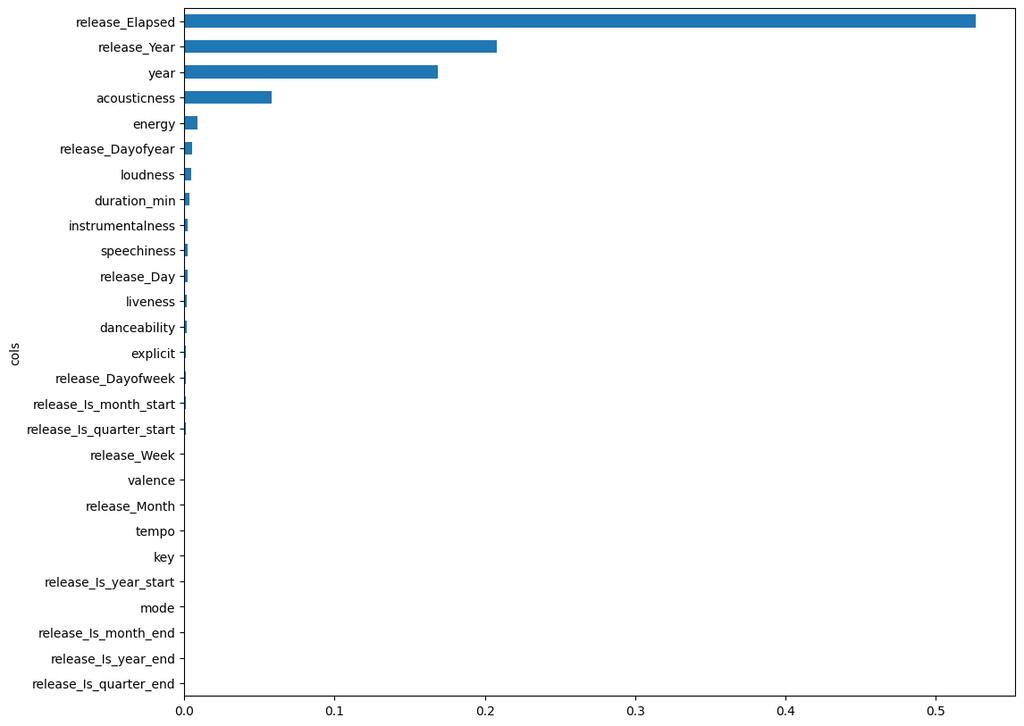

```python
barh = feat_importance[:30].plot('cols', 'imp', 'barh', figsize = (12,10), legend = False)
barh = barh.invert_yaxis()
barh
```

**It seems that popularity is strongly correlated to Release_Elapsed.** **Let's decrease max_features in our best model, to increase the chances to have trees not seeing these strong features.**

```python
best_model2 = RandomForestRegressor(
    n_estimators = 35,
    criterion = 'squared_error',

    # stoping criteria
    max_depth = 8,
    min_samples_split = 2,
    min_samples_leaf = 2,
    min_weight_fraction_leaf = 0.0,
    max_leaf_nodes = None,
    min_impurity_decrease = 0.0,
    ccp_alpha = 0.0,

    # bagging parameters
    max_features = 0.3,
    bootstrap = True,
    oob_score = True,
    max_samples = 0.75,

    # other
    warm_start = False,
    n_jobs = -1, # None
    random_state = 42, # None,
    verbose = 0,
)

%time best_model2.fit(X_small, y_small)
print_score(best_model2, X_small, y_small, X_valid, y_valid)
```

```
CPU times: total: 1.75 s
Wall time: 486 ms
RMSE on train set: 3.8250
RMSE on valid set: 6.3989
R^2 on train set: 0.9611
R^2 on valid set: 0.9075
R^2 on oob set: 0.9549
```

```python
best_model2 = RandomForestRegressor(
    n_estimators = 35,
    criterion = 'squared_error',

    # stoping criteria
    max_depth = 8,
    min_samples_split = 2,
    min_samples_leaf = 2,
    min_weight_fraction_leaf = 0.0,
    max_leaf_nodes = None,
    min_impurity_decrease = 0.0,
    ccp_alpha = 0.0,

    # bagging parameters
    max_features = 0.3,
    bootstrap = True,
    oob_score = True,
    max_samples = 0.75,

    # other
    warm_start = False,
    n_jobs = -1, # None
    random_state = 42, # None,
    verbose = 0,
)

%time best_model2.fit(X_train, y_train)
print_score(best_model2, X_train, y_train, X_valid, y_valid)
```

```
CPU times: total: 8.78 s
Wall time: 2.12 s
RMSE on train set: 9.8835
RMSE on valid set: 5.0989
R^2 on train set: 0.7946
R^2 on valid set: 0.9413
R^2 on oob set: 0.7891
```

```python
cv = KFold(n_splits = 8, shuffle = True, random_state = 42)

scores = cross_val_score(best_model2, X_small, y_small, cv = cv, n_jobs = -1)

print(scores)
print("r2 is {:.3f} with a standard deviation of {:.3f}".format(scores.mean(), scores.std()))
```

```
[0.94896893 0.95813833 0.95335504 0.95554161 0.95784199 0.95727936
 0.94721716 0.96045078]
r2 is 0.955 with a standard deviation of 0.004
```

```python
feat_importance = rf_feat_importance(best_model2, X_train)
feat_importance[:20]
```

|  | cols | imp |
| --- | --- | --- |
| 25 | release_Elapsed | 0.393446 |
| 13 | release_Year | 0.260762 |
| 12 | year | 0.173717 |
| 0 | acousticness | 0.080565 |
| 7 | loudness | 0.029527 |
| 2 | energy | 0.011922 |
| 16 | release_Day | 0.008856 |
| 20 | release_Is_month_start | 0.008821 |
| 18 | release_Dayofyear | 0.005382 |
| 9 | speechiness | 0.005332 |
| 22 | release_Is_quarter_start | 0.004182 |
| 4 | instrumentalness | 0.003857 |
| 26 | duration_min | 0.003051 |
| 3 | explicit | 0.002275 |
| 1 | danceability | 0.001618 |
| 17 | release_Dayofweek | 0.001469 |
| 6 | liveness | 0.001308 |
| 24 | release_Is_year_start | 0.000880 |
| 15 | release_Week | 0.000872 |
| 14 | release_Month | 0.000808 |

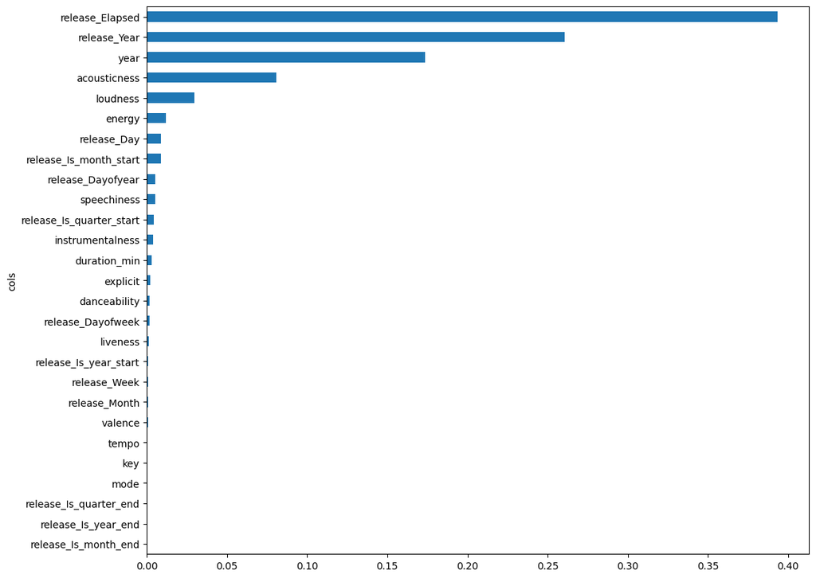

```python
barh = feat_importance[:30].plot('cols', 'imp', 'barh', figsize = (12,10), legend = False)
barh = barh.invert_yaxis()
barh
```

**By decreasing max_features from 0.5 to 0.3, not only the model generalise better and has a better R2 score on the valid set, it also reduces the importance of the strongest features.**

```python
to_keep = feat_importance[feat_importance.imp > 0.005].cols
len(to_keep)
```

```
10
```

```python
to_keep
```

```
25           release_Elapsed
13              release_Year
12                      year
0               acousticness
7                   loudness
2                     energy
16               release_Day
20    release_Is_month_start
18         release_Dayofyear
9                speechiness
Name: cols, dtype: object
```

```python
# perform ablation of columns with low importance
df_keep = df[to_keep].copy()

n_total = len(df_keep)
n_valid = 51000
n_train = n_total - n_valid
n_small = 20000

X_train_keep, X_valid_keep = split_vals(df_keep, n_train)
y_train, y_valid = split_vals(y, n_train)

X_small_keep, _ = split_vals(df_keep, n_small)
y_small, _ = split_vals(y, n_small)

print('Number of small training data points: X = {}, y = {}'.format(X_small.shape, y_small.shape))
print('Number of full training data points: X = {}, y = {}'.format(X_train.shape, y_train.shape))
print('Number of validation data points: X = {}, y = {}'.format(X_valid.shape, y_valid.shape))
```

```
Number of small training data points: X = (20000, 27), y = (20000,)
Number of full training data points: X = (118909, 27), y = (118909,)
Number of validation data points: X = (51000, 27), y = (51000,)
```

```python
best_model2 = RandomForestRegressor(
    n_estimators = 35,
    criterion = 'squared_error',

    # stoping criteria
    max_depth = 8,
    min_samples_split = 2,
    min_samples_leaf = 2,
    min_weight_fraction_leaf = 0.0,
    max_leaf_nodes = None,
    min_impurity_decrease = 0.0,
    ccp_alpha = 0.0,

    # bagging parameters
    max_features = 0.3,
    bootstrap = True,
    oob_score = True,
    max_samples = 0.75,

    # other
    warm_start = False,
    n_jobs = -1, # None
    random_state = 42, # None,
    verbose = 0,
)
%time best_model2.fit(X_small_keep, y_small)
print_score(best_model2, X_small_keep, y_small, X_valid_keep, y_valid)
```

```
CPU times: total: 812 ms
Wall time: 261 ms
RMSE on train set: 3.8595
RMSE on valid set: 6.4262
R^2 on train set: 0.9604
R^2 on valid set: 0.9067
R^2 on oob set: 0.9548
```

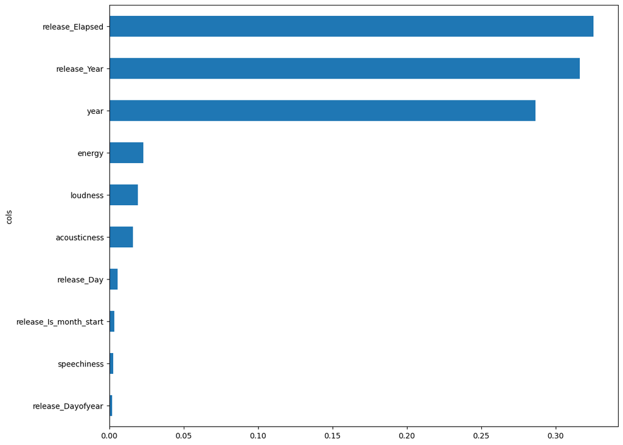

```python
feat_importance = rf_feat_importance(best_model2, X_small_keep)

barh = feat_importance.plot('cols', 'imp', 'barh', figsize = (12,10), legend = False)
barh = barh.invert_yaxis()
barh
```